# Analysis of Ft Riley white-tailed deer surveys

Why the disparity in confidence interval width between analysis that treats 2020 survey in isolation and analysis that includes 2020 in a model that uses all years’ data to produce year-specific density estimates?

Rexstad (CREEM, Univ St Andrews)https://www.creem.st-andrews.ac.uk/  
2021-10-28

# Supplement: Reconcile CIs of 2020 only with 2020 with other years

In the second deer practical, we analysed the 2020 survey as if it existed in isolation. The point estimate derived from that analysis, and from the analysis of all years combined (we will discuss next week) did not differ greatly, but the precision (confidence intervals) of the two estimates was substantially different. What is the reason for this?

Table 1: White-tailed deer estimates for 2020 analysed alone and analysed with other years.

| Label | Estimate | se | cv | lcl | ucl | df |
| --- | --- | --- | --- | --- | --- | --- |
| Analysed alone | 6.1486 | 1.0668 | 0.1735 | 4.3582 | 8.6746 | 62.7096 |
| Analysed with pooled detection fn | 5.1564 | 1.0800 | 0.2095 | 0.4573 | 58.1383 | 1.0367 |

When truncating 5% of only the 2020 data, truncation distance is 309m and 65 detections are included in the analysis. When 5% truncation is applied to the data pooled over all years, the truncation distance is shorter, 269m; with only 57 detections meeting that criterion.

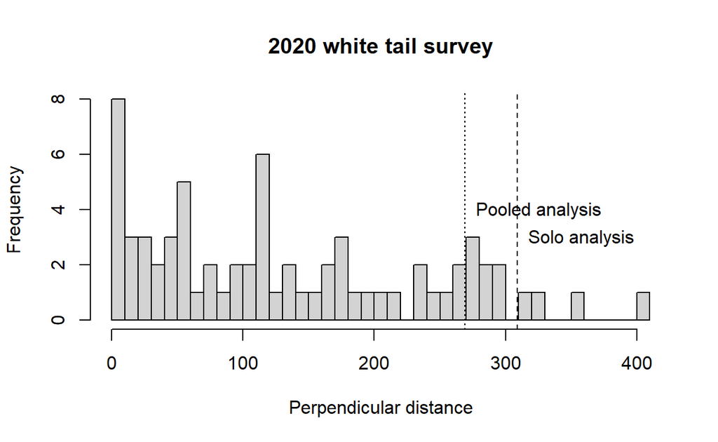

Figure 1: Distribution of perpendicular distances for 2020 white-tail survey. Vertical lines indicate truncation distances for solo (309m) and pooled (269m) analyses.

Confidence intervals in `Distance` are

- asymmetrical (based upon an distributional assumption of log-normal sampling distribution) and
- computed using degrees of freedom with the Sattherthwaite adjustment (see Buckland et al. (2001) Section 3.6.1)

$$d f=\frac{[\operatorname{cv}(\hat{D})]^{4}}{\sum_{i=1}^{q} \frac{\left[\mathrm{cv}_{i}\right]^{4}}{d f_{i}}}=\frac{\left[\sum_{i=1}^{q}\left[\mathrm{cv}_{i}\right]^{2}\right]^{2}}{\sum_{i=1}^{q} \frac{\left[\mathrm{cv}_{i}\right]^{4}}{d f_{i}}}$$

For the white-tailed deer surveys where animals are detected in groups, there are three sources of uncertainty, hence three CVs that enter the calculation: uncertainty in $\hat{P_a}$, variability in encounter rate and uncertainty in average group size.

Pull apart the estimation from the model `hnct` fitted in Practical 2 with the model `all.hr.pool` fitted in Practical 3, focusing our attention on this Sattherthwaite calculation; we compute the Sattherthwaite adjusted degrees of freedom for the two analyses.

$CV(ER_{pooled})$ is 6.54X $CV(ER_{alone})$ causing the ratio of CV(ER) to be >> than CV(P_a) with the pooled analysis. As a result, this situation described in Buckland et al. (2001:78) is in effect:

> It makes an noticable difference in confidence intervals for small $k$, especially if the ratio of $CV(ER)/CV(P_a)$ is greater than 1.

```r
cv <- vector("numeric", 3)
df <- vector("numeric", 3)

# uncertainty calculation for 2020 from analysis with all years
#    This is model all.hr.pool
cv <- c(0.0279848, 0.20757576, 0.0625997)   # p, er, sbar
df <- c(56, 1, 56)  # 57 detects, w=269

cv.dhat.just <- 0.20945368   #  .2952
dhat.just <- 5.156383   # 5.3571
df.dhat.just <- cv.dhat.just^4/sum(cv^4/df)
bigc <- exp((abs(qt(0.025, df.dhat.just)) * sqrt(log(1+cv.dhat.just^2))))
low.just <- dhat.just/bigc
high.just <- dhat.just * bigc

# uncertainty calculation for 2020 with that year analysed alone
#  This is model hnct from Prac2
cv <- c(0.1705737, 0.03171521, 0.06171404)   # p, er, sbar
df <- c(64, 1, 65)  # 65 detects, w=309
cv.dhat.only <- 0.1734971
dhat.only <- 6.148632
df.dhat.only <- cv.dhat.only^4/sum(cv^4/df)
bigc <- exp((abs(qt(0.025, df.dhat.only)) * sqrt(log(1+cv.dhat.only^2))))
low.only <- dhat.only/bigc
high.only <- dhat.only * bigc
outtable <- data.frame(df=c(df.dhat.only, df.dhat.just),
                       lcb=c(low.only, low.just),
                       ucb=c(high.only, high.just),
                       row.names = c("2020 analysed alone", "2020 with other years"))
kable(outtable, digits=3, caption="Sattherthwaite degrees of freedom impact on confidence interval bounds") %>%
  column_spec(2, bold=TRUE)
```

Table 2: Sattherthwaite degrees of freedom impact on confidence interval bounds

|  | df | lcb | ucb |
| --- | --- | --- | --- |
| 2020 analysed alone | 62.652 | 4.358 | 8.675 |
| 2020 with other years | 1.037 | 0.457 | 58.187 |

# In the end

Using an absolute truncation distance rather than a relative (percentage) truncation might have solved the dilemma.

Table 3: White-tailed deer estimates for 2020 analysed alone and analysed with other years using common truncation distance of 300m.

| Label | Estimate | se | cv | lcl | ucl | df |
| --- | --- | --- | --- | --- | --- | --- |
| Analysed alone | 6.0070 | 1.0754 | 0.1790 | 4.2122 | 8.5666 | 62.9831 |
| Analysed with pooled detection fn | 5.8914 | 0.2489 | 0.0422 | 5.1684 | 6.7155 | 3.1452 |

# The message

With few spatial replicates, chance plays a much greater role in estimation. An innocuous step in analysis (choosing “5%” truncation for both analyses) resulting in differing absolute truncation distances had a series of unintended consequences. Because of the differing truncation distances there were different groups of deer detected on the two transects in 2020. Those differences in the groups included in analysis resulted in different encounter rate variances. Those encounter rate variance differences influenced the Sattherthwaite degrees of freedom computation. The degrees of freedom difference (particularly the very small degrees of freedom for the pooled analysis) resulted in extreme differences in the upper confidence bound for the 2020 deer density estimate.

The message to remember is that the small number of spatial replicates cause relatively insignificant differences (the meaning of “5%”) to have **profound** consequences on the resulting estimates. More robust estimation, less sensitive to small changes, requires increased levels of spatial replication.